# Exploration

Jacob Johns

2023-11-03

# Data Exploration

## Read In Data

```r
traffic = read.csv("DenTraffic2019Train.csv")
traffic$SEGMDIR = as.factor(traffic$SEGMDIR)
traffic$FUNCCLASSI = as.factor(traffic$FUNCCLASSI)
traffic$SURFNAME = as.factor(traffic$SURFNAME)
```

## Feature Correlation

We will run a correlation on each of our quantitative features to ensure that we avoid the issue of multiple collinearity. We choose an alpha level of 0.70 so any features that share a correlation higher than that, one of them will be chosen to be omitted.

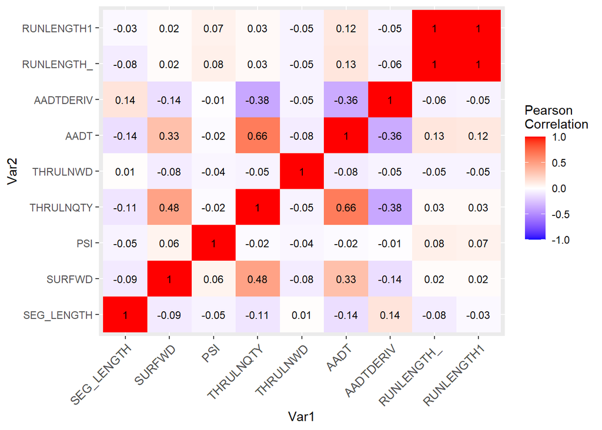

```r
numericData = subset(traffic, select = -c(X,ROUTENAME,SEGMDIR,FUNCCLASSI,SURFNAME,id))
cormat = round(cor(numericData),2)
cormat <- melt(cormat)
heatMap = ggplot(data = cormat, aes(x=Var1,y=Var2,fill=value))
heatMap = heatMap + geom_tile()
heatMap = heatMap + scale_fill_gradient2(low = "blue", high = "red", mid = "white",
   midpoint = 0, limit = c(-1,1), space = "Lab",
   name="Pearson\nCorrelation")
heatMap = heatMap + theme(axis.text.x = element_text(angle = 45, vjust = 1,
    size = 10, hjust = 1))
heatMap = heatMap + geom_text(aes(Var2, Var1, label = value), color = "black", size = 3)
heatMap
```

Here we see that $\verb|RUNLENGTH_|$ and $\verb|RUNLENGTH1|$ are actually the same variable. Accordingly, we’ll remove one of them. It appears that there are no other correlations to be concerned about, but we will verify that later in the modeling section.

## Data Quality

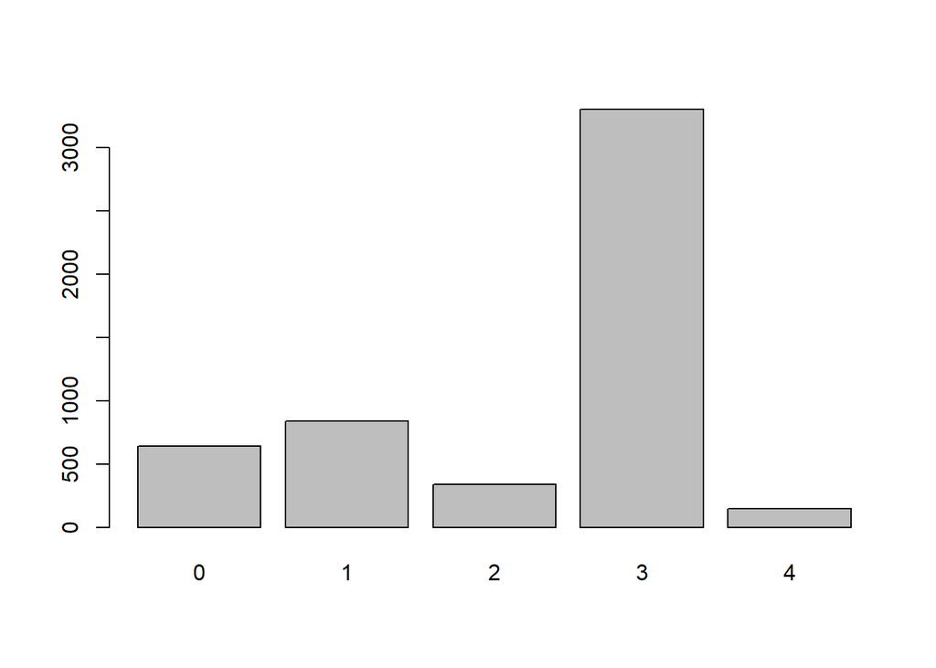

```r
barplot(table(traffic$AADTDERIV))
```

This is shows how many years since the $\verb|AADT|$ data was collected, except for the values of 4, which are defined by the data set to be estimated. We believe using estimated/calculated values to predict data will lead the model to fit the estimation the dataset owners used. Accordingly, we will remove those observations.

```r
traffic = subset(traffic,traffic$AADTDERIV!=4)
```

## Summarization

```r
summary(traffic)
```

```
##        X          SEG_LENGTH       ROUTENAME            SEGMDIR
##  Min.   :   1   Min.   :0.00100   Length:5118        E      :1728
##  1st Qu.:1319   1st Qu.:0.04000   Class :character   W      : 933
##  Median :2640   Median :0.06000   Mode  :character   N      : 921
##  Mean   :2637   Mean   :0.06717                      S      : 726
##  3rd Qu.:3950   3rd Qu.:0.08000                      NE     : 383
##  Max.   :5267   Max.   :1.07000                      NW     : 253
##                                                      (Other): 174
##                          FUNCCLASSI                        SURFNAME
##  3  Principal Arterial - Other:1017   1    Asphalt             :4975
##  4  Minor Arterial            :1834   16  Soil, Gravel or Stone:   6
##  5  Major Collector           :2267   3    Concrete            : 137
##
##
##
##
##      SURFWD            PSI          THRULNQTY       THRULNWD         AADT
##  Min.   : 20.00   Min.   :1.000   Min.   :1.00   Min.   : 9.0   Min.   :   40
##  1st Qu.: 34.00   1st Qu.:2.500   1st Qu.:2.00   1st Qu.:10.0   1st Qu.: 4700
##  Median : 40.00   Median :4.000   Median :2.00   Median :10.0   Median : 8400
##  Mean   : 44.86   Mean   :3.454   Mean   :2.76   Mean   :10.5   Mean   :11980
##  3rd Qu.: 48.00   3rd Qu.:4.000   3rd Qu.:4.00   3rd Qu.:11.0   3rd Qu.:17750
##  Max.   :170.00   Max.   :4.000   Max.   :8.00   Max.   :18.0   Max.   :66000
##
##    AADTDERIV      RUNLENGTH_      RUNLENGTH1          id
##  Min.   :0.00   Min.   :0.000   Min.   :0.010   Min.   :   1
##  1st Qu.:1.00   1st Qu.:0.330   1st Qu.:0.400   1st Qu.:1682
##  Median :3.00   Median :0.760   Median :0.830   Median :3344
##  Mean   :2.23   Mean   :1.052   Mean   :1.119   Mean   :3321
##  3rd Qu.:3.00   3rd Qu.:1.515   3rd Qu.:1.580   3rd Qu.:4966
##  Max.   :3.00   Max.   :6.099   Max.   :6.479   Max.   :6581
##
```

From our summaries, we can see that there isn’t really enough support for using $\verb|SURFNAME|$ as a predictor variable

## Feature Selection

```r
traffic = subset(traffic, select = -c(X,RUNLENGTH_,id,SURFNAME))
```

## Export

```r
write.csv(traffic , file = "DenTraffic2019ToModel.csv")
```